# Fourth Week: Hypothesis Testing

TIMSS Analysis

Seyederfan Hosseini _ 93101373

2018-03-08 21:34:43

# تمرین سری چهارم: چقدر ریاضی بلدیم و چرا؟

لطفا مقاله زیر را مطالعه بفرمایید.

[چرایی رتبه ضعیف ایران در آزمون تیمز](https://goo.gl/gX8DZc)

> با استفاده از داده های ارزیابی تیمز ۲۰۱۵ ادعاهای زیر را مورد ارزیابی قراردهید. برای هر سوال علاوه بر استدلال آماری که در غالب آزمون فرض تعریف می شود از تصویرسازی مناسب باهر دو ابزار ggplot2 و highcharter استفاده نمایید. به دلخواه به هفت گزاره از موارد زیر پاسخ دهید.

```r
rm(list = ls())
library(readr)
library(highcharter)
library(dplyr)
library(ggplot2)
path = '~/R/HW4/hw_04/Data'
stdBG = read_rds(paste(path,'bsg.rds', sep= '/'))
```

۱. میران رضایت معلمان در پیشرفت تحصیلی دانش آموزان موثر است.

```r
teacherBG = read_rds(paste(path,'btm.rds', sep= '/'))
teacherBG %>% select(idcntry ,idteach , sat = btbgtjs) %>% na.omit() -> teacherSat
stdBG %>% select(idcntry, idstud, 290:299 ) %>% na.omit() -> stdPerf
stdPerf['perf'] = rowMeans(stdPerf[3:12])
stdPerf %>% select(idcntry ,idstud, perf) -> stdPerf
linkage = read_rds(paste(path,'bst.rds', sep= '/'))
linkage %>% select(idcntry ,idstud, idteach) %>% na.omit() -> link
stat = full_join(link, stdPerf, by=c('idcntry', 'idstud'))
stat = full_join(teacherSat, stat, by=c('idcntry', 'idteach'))
stat %>% na.omit() -> stat
stat %>% group_by(idcntry, idteach) %>% summarise(teacherSat = mean(sat), stdPerf = mean(perf)) -> con1
con2 = con1
con2$teacherSat = round(con2$teacherSat)
con2 %>% group_by(teacherSat) %>% summarise(stdPerf = mean(stdPerf)) -> con
```

نمودار میانگین عملکرد دانش آموزان براساس میزان رضایت معلمان توسط highcharter:

```r
hchart(con, hcaes(x = teacherSat, y= stdPerf), type = 'line') %>%
    hc_yAxis(title = list(text = 'Mean of Students Performance')) %>%
    hc_title(text= 'Student Performance VS Teacher Satisfaction Level') %>%
    hc_xAxis(title = list(text = 'Teacher Satisfaction'))
```

[interactive chart not shown]

همین نمودار توسط ggplot:

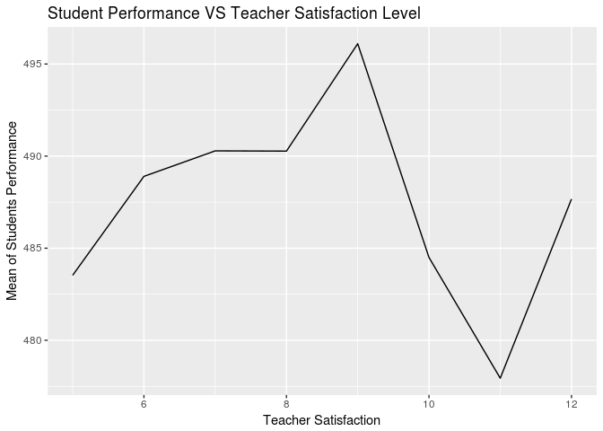

```r
ggplot(data = con, aes(x = teacherSat, y= stdPerf)) + geom_line() +
    xlab('Teacher Satisfaction') + ylab('Mean of Students Performance') +
    ggtitle('Student Performance VS Teacher Satisfaction Level')
```

نتیجه آزمون فرض correlation بر روی نتایج بدست آمده به شرح زیر است:

```r
cor.test(con1$teacherSat, con1$stdPerf)
```

```
##
##  Pearson's product-moment correlation
##
## data:  con1$teacherSat and con1$stdPerf
## t = -3.1307, df = 11772, p-value = 0.001748
## alternative hypothesis: true correlation is not equal to 0
## 95 percent confidence interval:
##  -0.04688107 -0.01078476
## sample estimates:
##         cor
## -0.02884232
```

همانگونه که در نتیجه تست دیده می شود p-value کمتر از 0.05 است بنابراین ۲ متغیر وابسته اند.د.

```r
rm(con, link, linkage, stat, stdPerf, teacherBG, teacherSat)
```

۲. والدینی که تحصیلات بیشتری دارند دارای فرزندان موفق تری می باشند.

نمودار میانگین عملکرد دانش آموزان براساس میانگین تحصیلات والدین توسط highcharter:

```r
stdBG %>% select(eduMoth = bsbg07a, eduFath = bsbg07b, 290:299 ) %>% filter(eduFath != 8) %>% filter(eduMoth !=8) %>% na.omit() -> stdEdu
stdEdu['perf'] = rowMeans(stdEdu[3:12], na.rm = T)
stdEdu %>% select(eduMoth, eduFath, perf ) %>% mutate(edu = (eduMoth + eduFath)/2) %>% select(edu, perf) %>% na.omit() -> stdEdu
stdEdu %>% group_by(edu) %>% summarise(meanPerf = mean(perf)) -> meanStdEdu
hchart(meanStdEdu, hcaes(x = edu, y= meanPerf), type = 'line') %>%
    hc_yAxis(title = list(text = 'Mean of Student Performance')) %>%
    hc_title(text= 'Student Performance VS Parent Education level') %>%
    hc_xAxis(title = list(text = 'Mean of Parent Education Level'))
```

[interactive chart not shown]

همین نمودار توسط ggplot:

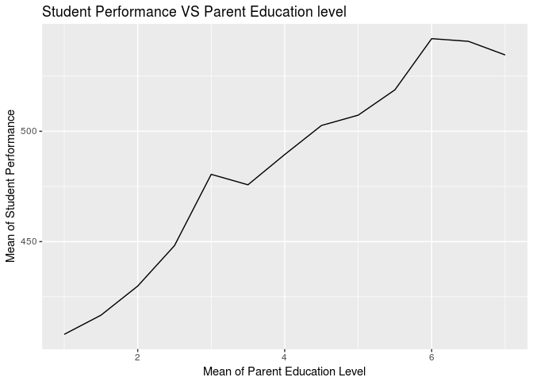

```r
p = ggplot(data = meanStdEdu, aes(x = edu, y= meanPerf))
p + geom_line() + ggtitle('Student Performance VS Parent Education level') + xlab('Mean of Parent Education Level') +
    ylab('Mean of Student Performance')
```

نتیجه آزمون فرض correlation بر روی نتایج بدست آمده به شرح زیر است:

```r
cor.test(stdEdu$edu, stdEdu$perf)
```

```
##
##  Pearson's product-moment correlation
##
## data:  stdEdu$edu and stdEdu$perf
## t = 171.11, df = 168490, p-value < 2.2e-16
## alternative hypothesis: true correlation is not equal to 0
## 95 percent confidence interval:
##  0.3806862 0.3888221
## sample estimates:
##       cor
## 0.3847616
```

```r
rm(stdEdu, meanStdEdu)
```

بنابر نتیجه آزمون مقدار p-value برای مستقل بودن دو بردار تقریبا صفر است پس دو متغییر به هم وابسته اند. طبق نمودار های رسم شده با افزایش میزان تحصیلات والدین میزان عملکرد فرزندانشان بالاتر می رود بنابراین گزاره مطرح شده تایید می شود.

۳. امکانات رفاهی در خانه موجب پیشرفت تحصیلی می گردد.

نمودار میانگین عملکرد دانش آموزان براساس میزان امکانات موجود در خانه توسط highcharter:

```r
stdBG %>% select(12:24, 290:299) %>% na.omit() %>%
    mutate(tablet = case_when(bsbg06a == 1 & bsbg06b == 2 ~ 5,
                          bsbg06a == 1 & bsbg06b == 1 ~ 3.667,
                          bsbg06a == 2 & bsbg06b == 1 ~ 2.333,
                          bsbg06a == 2 & bsbg06b == 2 ~ 1),
        desk = ifelse(bsbg06c == 1, 5, 1),
       room = ifelse(bsbg06d == 1, 5, 1),
       internet = ifelse(bsbg06e == 1, 5, 1),
       mobile = ifelse(bsbg06f == 1, 5, 1),
       game = ifelse(bsbg06g == 1, 5, 1),
       c1 = ifelse(bsbg06h == 1, 5, 1),
       c2 = ifelse(bsbg06i == 1, 5, 1),
       c3 = ifelse(bsbg06j == 1, 5, 1),
       c4 = ifelse(bsbg06k == 1, 5, 1)) %>%
    select(1:2, tablet, desk, room, internet, mobile, game, c1, c2, c3, c4, 14:23)-> stdPoss
stdPoss['refah'] = rowMeans(stdPoss[1:12])
stdPoss['perf'] = rowMeans(stdPoss[13:22], na.rm = T)
stdPoss %>% select(refah, perf) -> stdPoss
stdPoss$refah = round(stdPoss$refah, 1)
stdPoss %>% group_by(refah) %>% summarise(meanPerf = mean(perf)) -> stdPoss
hchart(stdPoss, hcaes(x = refah, y= meanPerf), type = 'line') %>%
    hc_yAxis(title = list(text = 'Mean of Student Performance')) %>%
    hc_title(text= 'Performance VS Home Prosperity') %>%
    hc_xAxis(title = list(text = 'Mean of Home Prosperity'))
```

[interactive chart not shown]

همین نمودار توسط ggplot:

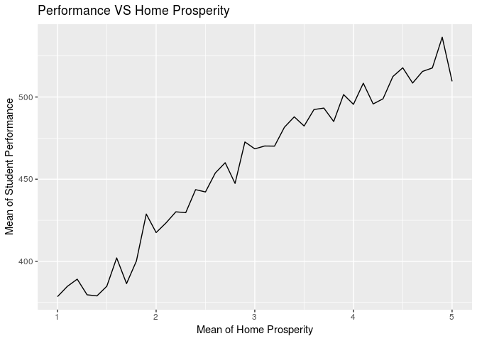

```r
p = ggplot(data = stdPoss, aes(x = refah, y= meanPerf))
p + geom_line() + ggtitle('Performance VS Home Prosperity') + xlab('Mean of Home Prosperity') + ylab('Mean of Student Performance')
```

نتیجه آزمون فرض correlation بر روی نتایج بدست آمده به شرح زیر است:

```r
cor.test(stdPoss$refah, stdPoss$meanPerf)
```

```
##
##  Pearson's product-moment correlation
##
## data:  stdPoss$refah and stdPoss$meanPerf
## t = 28.115, df = 39, p-value < 2.2e-16
## alternative hypothesis: true correlation is not equal to 0
## 95 percent confidence interval:
##  0.9555322 0.9873317
## sample estimates:
##       cor
## 0.9762071
```

```r
rm(stdPoss)
```

بنابر نتیجه آزمون مقدار p-value برای وابسته نبودن ۲ بردار تقریبا صفر است پس دو متغییر به هم وابسته اند. طبق نمودار های رسم شده نیز با افزایش سطح میزان امکانات خانه میزان عملکرد دانش آموزان بالاتر می رود پس گزاره صورت سوال تایید می گردد.

۶. پسران در کاربرد هندسه قوی تر هستند.

نمودار میانگین عملکرد پسران و دختران در هندسه توسط highcharter:

```r
stdBG %>% select(idstud, itsex , 315:319) -> stdGeo
stdGeo$stdPer = rowMeans(stdGeo[3:7])
stdGeo %>% select(itsex, stdPerf = stdPer) %>% na.omit() -> stdGeo
stdGeo %>% group_by(itsex) %>% summarise(geoPerf = mean(stdPerf)) -> stdGeoPlot
stdGeoPlot %>% mutate(sex = case_when(itsex == 1 ~ 'Female',
                                      itsex == 2 ~ 'Male')) %>% select(sex, geoPerf) -> stdGeoPlot
hchart(stdGeoPlot, hcaes(x = sex, y= geoPerf), type = 'column') %>%
    hc_yAxis(title = list(text = 'Mean of Geometry Performance')) %>%
    hc_title(text= 'Geometry Performance VS Sex') %>%
    hc_xAxis(title = list(text = 'Sex'))
```

[interactive chart not shown]

همین نمودار توسط ggplot:

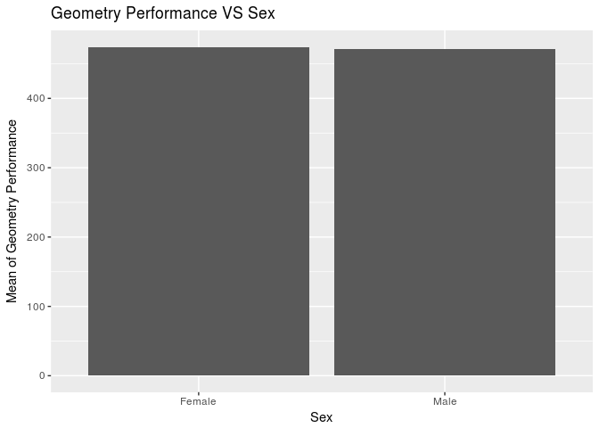

```r
ggplot(data = stdGeoPlot, aes(x = sex, y= geoPerf)) +
    geom_bar(stat = 'identity') +
    xlab('Sex') + ylab('Mean of Geometry Performance') +
    ggtitle('Geometry Performance VS Sex')
```

نتیجه آزمون فرض t بر روی نتایج بدست آمده با شرط ثانویه کوچکتر بودن به شرح زیر است:

```r
t.test(stdGeo$stdPerf[which(stdGeo$itsex == 2)], stdGeo$stdPerf[which(stdGeo$itsex == 1)],alternative = 'less')
```

```
##
##  Welch Two Sample t-test
##
## data:  stdGeo$stdPerf[which(stdGeo$itsex == 2)] and stdGeo$stdPerf[which(stdGeo$itsex == 1)]
## t = -9.2376, df = 279150, p-value < 2.2e-16
## alternative hypothesis: true difference in means is less than 0
## 95 percent confidence interval:
##      -Inf -3.13238
## sample estimates:
## mean of x mean of y
##  470.5604  474.3713
```

```r
rm(stdGeo, stdGeoPlot)
```

بنابر نتیجه آزمون فرض، مقدار p-value برای بزرگتر بودن میانگین عملکرد پسران در هندسه تقریبا صفر است بنابراین این فرض که پسران در هندسه قوی تر هستند رد می شود.

۸. مدارس با امکانات بیشتر دارای عملکرد بهتری می باشند.

نمودار میانگین عملکرد دانش آموزان بر اساس میزان امکانات مدرسه توسط highcharter:

```r
stdBG %>% select(idcntry,idschool, idstud, 290:299 ) %>% na.omit() -> stdPerf
stdPerf['perf'] = rowMeans(stdPerf[4:13])
stdPerf %>% select(idcntry, idschool, idstud, perf) -> stdPerf
schBG = read_rds(paste(path,'bcg.rds', sep= '/'))
schBG %>% select(idcntry, idschool, 13:14, numPC = 17, 28:43 ) -> rep
rep %>% mutate(bcbg08a = case_when(bcbg08a == 2~4), bcbg08b = case_when(bcbg08b == 2~4),
               numPC = case_when(numPC > 1000 ~ 1 ,
                                 ((numPC<= 1000) & (numPC > 500)) ~ 2,
                                 ((numPC <=500) & (numPC > 250)) ~ 3,
                                 numPC <= 250 ~ 4)) -> rep
rep$refah = rowMeans(rep[3:21], na.rm = T)
rep %>% select(idcntry, idschool, refah) -> rep
rep$refah = 5 - rep$refah
rep = rep[which(rep$refah != 'NaN'),]
rep$refah = round(rep$refah * 5)
rep = full_join(rep, stdPerf)
```

```r
rep %>% na.omit() %>% group_by(idcntry, idschool) %>% summarise(refah = mean(refah, na.rm = T), meanPerf = mean(perf, na.rm = T) ) -> rep
rep %>% group_by(refah) %>% summarise(meanPerf = mean(meanPerf)) -> rep1
hchart(rep1, hcaes(x = refah, y = meanPerf), type = 'line') %>%
    hc_yAxis(title = list(text = 'Mean of Student Performance')) %>%
    hc_title(text= 'Student Performance VS School Properties') %>%
    hc_xAxis(title = list(text = 'School Properties'))
```

[interactive chart not shown]

همین نمودار توسط ggplot:

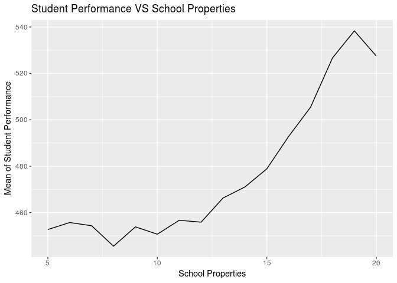

```r
ggplot(data = rep1, aes(x = refah, y = meanPerf)) + geom_line() +
    xlab('School Properties') + ylab('Mean of Student Performance') +
    ggtitle('Student Performance VS School Properties')
```

نتیجه آزمون فرض correlation بر روی نتایج بدست آمده به شرح زیر است:

```r
cor.test(rep$refah, rep$meanPerf)
```

```
##
##  Pearson's product-moment correlation
##
## data:  rep$refah and rep$meanPerf
## t = 29.148, df = 8027, p-value < 2.2e-16
## alternative hypothesis: true correlation is not equal to 0
## 95 percent confidence interval:
##  0.2894586 0.3290213
## sample estimates:
##       cor
## 0.3093738
```

بنابر نتیجه آزمون، مقدار p-value برای وابسته نبودن ۲ بردار تقریبا صفر است پس دو متغییر به هم وابسته اند. طبق نمودار های رسم شده نیز با افزایش میزان امکانات مدرسه میزان عملکرد دانش آموزان بالاتر می رود پس گزاره صورت سوال تایید می گردد.

۹. علت افت تحصیلی عدم مشارکت در کلاس است.

نمودار میانگین عملکرد دانش آموزان بر اساس میزان حضور در کلاس توسط highcharter:

```r
stdBG %>% select(32, 290:299) -> abs
abs$perf = rowMeans(abs[2:11])
abs %>% select(absence = 1, perf) %>% na.omit() -> abs
abs %>% group_by(absence) %>% summarise(meanPerf = mean(perf)) -> absRep
hchart(absRep, hcaes(x= absence, y = meanPerf), type='line') %>%
    hc_yAxis(title = list(text = 'Mean of Student Performance')) %>%
    hc_title(text= 'Student Performance VS Class Participation') %>%
    hc_xAxis(title = list(text = 'Class Participation'))
```

[interactive chart not shown]

همین نمودار توسط ggplot:

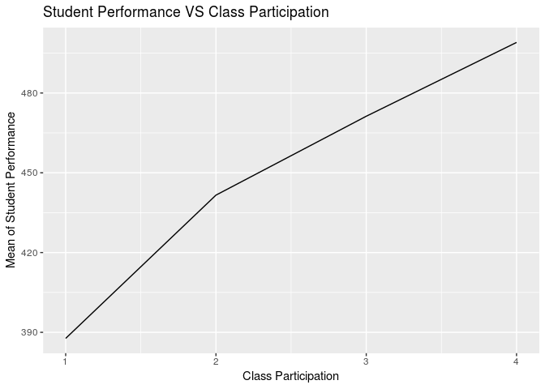

```r
p = ggplot(data = absRep, aes(x= absence, y = meanPerf)) +
    ggtitle('Student Performance VS Class Participation') +
    xlab('Class Participation') +
    ylab('Mean of Student Performance')
p + geom_line()
```

نتیجه آزمون فرض correlation بر روی نتایج بدست آمده به شرح زیر است:

```r
cor.test(abs$absence, abs$perf)
```

```
##
##  Pearson's product-moment correlation
##
## data:  abs$absence and abs$perf
## t = 164.49, df = 264980, p-value < 2.2e-16
## alternative hypothesis: true correlation is not equal to 0
## 95 percent confidence interval:
##  0.3009304 0.3078398
## sample estimates:
##       cor
## 0.3043891
```

```r
rm(abs, absRep)
```

بنابر نتیجه آزمون، مقدار p-value برای وابسته نبودن ۲ بردار تقریبا صفر است پس دو متغییر به هم وابسته اند. طبق نمودار های رسم شده نیز با افزایش میزان حضور در کلاس میزان عملکرد دانش آموزان بالاتر می رود پس گزاره صورت سوال تایید می گردد.

۱۰. دانش آموزان ایرانی در استدلال قوی تر از کاربرد هستند.

نمودار میانگین عملکرد دانش آموزان ایرانی در استدلال و کاربرد توسط highcharter:

```r
stdBG %>% filter(idcntry == 364) %>% select(345:349, 360:364, 350:354, 365:369 ) ->iranEdu
iranEdu$reasoning = rowMeans(iranEdu[11:20], na.rm = T)
iranEdu$applying = rowMeans(iranEdu[1:10], na.rm = T)
iranEdu %>% select(reasoning, applying) -> iranEdu
tmp = data.frame(matrix(data = NA))
tmp[1, 1] = 'Applying'
tmp[1, 2] = mean(iranEdu$applying)
tmp[2, 1] = 'Reasoning'
tmp[2, 2] = mean(iranEdu$reasoning)
tmp %>% select(Gender = matrix.data...NA., Perfomance = V2) -> tmp
hchart(tmp, hcaes(x= Gender, y= Perfomance), type = 'column') %>%
    hc_yAxis(title = list(text = 'Mean of Performance')) %>%
    hc_title(text= 'Performance VS Question Category') %>%
    hc_xAxis(title = list(text = 'Category'))
```

[interactive chart not shown]

همین نمودار توسط ggplot:

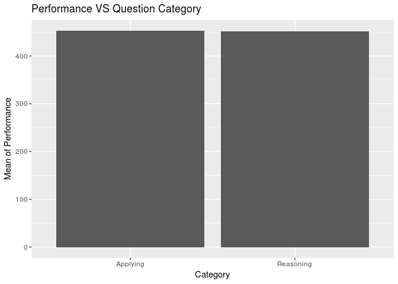

```r
ggplot(data = tmp, aes(x= Gender, y= Perfomance)) + geom_bar(stat = 'identity') +
    xlab('Category') + ylab('Mean of Performance') +
    ggtitle('Performance VS Question Category')
```

نتیجه آزمون فرض t بر روی نتایج بدست آمده با شرط ثانویه کوچکتر بودن به شرح زیر است:

```r
t.test(iranEdu$reasoning, iranEdu$applying, alt= 'less')
```

```
##
##  Welch Two Sample t-test
##
## data:  iranEdu$reasoning and iranEdu$applying
## t = -0.40608, df = 12235, p-value = 0.3423
## alternative hypothesis: true difference in means is less than 0
## 95 percent confidence interval:
##      -Inf 1.918717
## sample estimates:
## mean of x mean of y
##  451.7581  452.3870
```

```r
rm(iranEdu, tmp)
```

همانگونه که در نتیجه تست دیده می شود با p-value برابر 0.342 نمی توان در مورد بزرگتر بودن میانگین استدلال در مقابل کاربرد نظری داد.

سه گزاره جالب کشف کنید و ادعای خود را ثابت نمایید.

گزاره اول : بررسی تاثیر علاقه دانش آموزان در عملکرد آن ها در ریاضی و علوم

نمودار عملکرد دانش آموزان در درس های ریاضی و علوم توسط highcharter:

```r
stdBG %>% select(290:299, mathLike = bsbgslm, scLike = bsbgsls ) -> rep
rep['mathPerf'] = rowMeans(rep[1:5], na.rm = T)
rep['scPerf'] = rowMeans(rep[6:10], na.rm = T)
rep %>% select(mathLike, scLike, mathPerf, scPerf) %>% na.omit() -> rep
rep$mathLike = round(rep$mathLike)
rep$scLike = round(rep$scLike)
rep %>% group_by(mathLike) %>% summarise(meanPerf = mean(mathPerf)) -> mathRep
rep %>% group_by(scLike) %>% summarise(meanPerf = mean(scPerf)) -> scRep
hchart(mathRep, hcaes(x = mathLike, y= meanPerf), type = 'line') %>%
    hc_yAxis(title = list(text = 'Mean of Performance')) %>%
    hc_title(text= 'Math Performance VS Math Interest') %>%
    hc_xAxis(title = list(text = 'Math Interest'))
```

[interactive chart not shown]

```r
hchart(scRep, hcaes(x = scLike, y= meanPerf), type = 'line') %>%
    hc_yAxis(title = list(text = 'Mean of Performance')) %>%
    hc_title(text= 'Science Performance VS Science Interest') %>%
    hc_xAxis(title = list(text = 'Science Interest'))
```

[interactive chart not shown]

همین نمودار توسط ggplot:

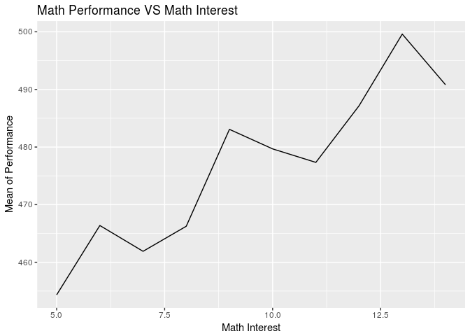

```r
ggplot(data = mathRep, aes(x = mathLike, y= meanPerf)) + geom_line() +
    xlab('Math Interest') + ylab('Mean of Performance') +
    ggtitle('Math Performance VS Math Interest')
```

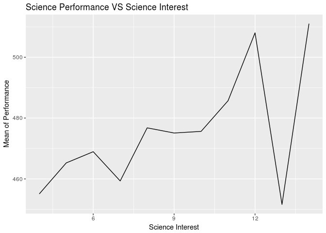

```r
ggplot(data = scRep, aes(x = scLike, y= meanPerf)) + geom_line() +
    xlab('Science Interest') + ylab('Mean of Performance') +
    ggtitle('Science Performance VS Science Interest')
```

نتیجه آزمون فرض correlation بر روی نتایج بدست آمده به شرح زیر است:

```r
cor.test(mathRep$mathLike, mathRep$meanPerf)
```

```
##
##  Pearson's product-moment correlation
##
## data:  mathRep$mathLike and mathRep$meanPerf
## t = 6.9269, df = 8, p-value = 0.0001212
## alternative hypothesis: true correlation is not equal to 0
## 95 percent confidence interval:
##  0.7100747 0.9826373
## sample estimates:
##      cor
## 0.925795
```

```r
cor.test(scRep$scLike, scRep$meanPerf)
```

```
##
##  Pearson's product-moment correlation
##
## data:  scRep$scLike and scRep$meanPerf
## t = 2.2947, df = 9, p-value = 0.04741
## alternative hypothesis: true correlation is not equal to 0
## 95 percent confidence interval:
##  0.01207917 0.88491502
## sample estimates:
##       cor
## 0.6075519
```

همانگونه که در نتیجه تست دیده می شود هر ۲ مقدار p-value کمتر از 0.05 است بنابراین ۲ متغیر وابسته اند.

گزاره دوم: تاثیر میزان زمان صرف شده برای ریاضیات در نتیجه ریاضیات

نمودار میانگین عملکرد دانش آموزان بر اساس میزان زمان صرف شده برای ریاضیات توسط highcharter:

```r
stdBG %>% select(290:294, mathTime = bsdmwkhw, scTime = bsdswkhs ) -> rep
rep['mathPerf'] = rowMeans(rep[1:5], na.rm = T)
rep$mathTime = 4 - rep$mathTime
rep %>% select(mathPerf, mathTime) %>% na.omit() -> rep
rep %>% group_by(mathTime) %>% summarise(meanPerf = mean(mathPerf)) -> mathRep
hchart(mathRep, hcaes(x = mathTime, y= meanPerf), type = 'line') %>%
    hc_yAxis(title = list(text = 'Mean of Math Performance')) %>%
    hc_title(text= 'Math Performance VS Math Time') %>%
    hc_xAxis(title = list(text = 'Math Time'))
```

[interactive chart not shown]

همین نمودار توسط ggplot:

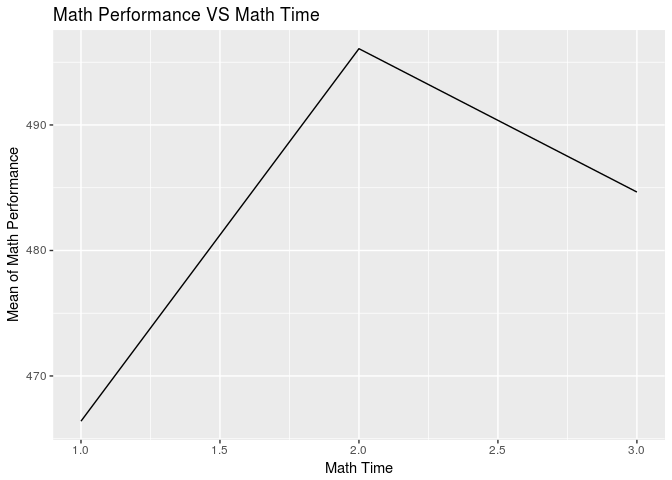

```r
ggplot(data = mathRep, aes(x = mathTime, y= meanPerf)) + geom_line() +
    xlab('Math Time') + ylab('Mean of Math Performance') +
    ggtitle('Math Performance VS Math Time')
```

نتیجه آزمون فرض correlation بر روی نتایج بدست آمده به شرح زیر است:

```r
cor.test(rep$mathPerf, rep$mathTime)
```

```
##
##  Pearson's product-moment correlation
##
## data:  rep$mathPerf and rep$mathTime
## t = 49.833, df = 267580, p-value < 2.2e-16
## alternative hypothesis: true correlation is not equal to 0
## 95 percent confidence interval:
##  0.09213644 0.09964468
## sample estimates:
##        cor
## 0.09589192
```

همانگونه که در نتیجه تست دیده می شود هر ۲ مقدار p-value کمتر از 0.05 است بنابراین ۲ متغیر وابسته اند.

گزاره سوم: تاثیر میزان تجربه مدیران بر عملکرد دانش آموزان مدرسه.

نمودار میانگین عملکرد دانش آموزان بر حسب میزان تجربه مدیران

```r
schBG = read_rds(paste(path,'bcg.rds', sep= '/'))
schBG %>% select(idcntry, idschool, exp = bcbg19) %>% na.omit() -> schRep
stdBG %>% select(idcntry,idschool, idstud, 290:299 ) -> stdPerf
stdPerf['perf'] = rowMeans(stdPerf[4:13], na.rm = T)
stdPerf %>% select(idcntry, idschool, idstud, perf) %>% na.omit() -> stdPerf
rep = full_join(schRep, stdPerf)
```

```r
rep %>% na.omit() %>%  group_by(idcntry, idschool) %>% summarise(exp = mean(exp, na.rm = T), meanPerf = mean(perf, na.rm = T)) -> rep1
rep1 %>% group_by(exp) %>% summarise(meanPerf = mean(meanPerf)) -> rep
hchart(rep, hcaes(x = exp, y = meanPerf), type = 'line') %>%
    hc_yAxis(title = list(text = 'Mean of Performance')) %>%
    hc_title(text= 'Math Performance VS Manager Experience') %>%
    hc_xAxis(title = list(text = 'Manager Experience'))
```

[interactive chart not shown]

همین نمودار توسط ggplot:

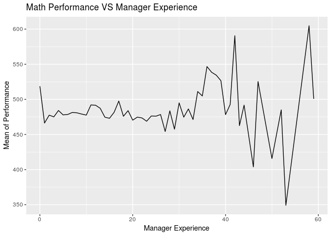

```r
ggplot(data = rep, aes(x = exp, y = meanPerf)) + geom_line() +
    xlab('Manager Experience') + ylab('Mean of Performance') +
    ggtitle('Math Performance VS Manager Experience')
```

نتیجه آزمون فرض correlation بر روی نتایج بدست آمده به شرح زیر است:

```r
cor.test(rep1$exp, rep1$meanPerf)
```

```
##
##  Pearson's product-moment correlation
##
## data:  rep1$exp and rep1$meanPerf
## t = 2.7288, df = 7759, p-value = 0.006372
## alternative hypothesis: true correlation is not equal to 0
## 95 percent confidence interval:
##  0.00872125 0.05317569
## sample estimates:
##        cor
## 0.03096378
```

همانگونه که در نتیجه تست دیده می شود هر ۲ مقدار p-value کمتر از 0.05 است بنابراین ۲ متغیر وابسته اند.